# Chinese Characters vs. Strokes

Chris Bentz

06.03.2025

# Description

This file provides functionality for plotting feature value distributions in density plots. This file in particular focuses on the difference between Chinese complex characters and individual strokes. See the file preprocess_TeDDi.Rmd for further details on the mapping.

# Session Info

Give the session info (reduced).

```
## [1] "R version 4.3.3 (2024-02-29)"
```

```
## [1] "x86_64-pc-linux-gnu"
```

# Load libraries

If the libraries are not installed yet, you need to install them using, for example, the command: install.packages(“ggplot2”).

```r
library(ggplot2)
library(ggrepel)
library(ggExtra)
library(ggpubr)
library(ggridges)
```

Give the package versions.

```
## ggridges   ggpubr  ggExtra  ggrepel  ggplot2
##  "0.5.6"  "0.6.0" "0.10.1"  "0.9.6"  "3.5.1"
```

# Load Data

Load csv file with quantitative feature values for a comparative sample of feature values for languages across the world. This is derived from the Text Data Diversity (TeDDi) sample (Moran et al 2022).

```r
estimations.df <- read.csv("~/Github/PaleoSigns/results/features/teddi_features.csv")
head(estimations.df)
```

```
##       id
## 1   7983
## 2  20443
## 3 309901
## 4 137860
## 5 410735
## 6 393591
##                                                                                                                                                                                          text
## 1 Na nd mounmotrhu mrokfot inji wanyhato duka memoya nhai wom hefenr tohyuk frohrn o bbinysoft tohyuk frohrn o yiro Maringour tohyuk frohrn nd skrorkfot yak nyusakuhato yiro mrokfom htikfot
## 2                                                                                            Setxi itaritxiakori aua mitxi ĩkorapokoriti  Apia kiomanetakari ĩtaniriuata  Meenetipanika ipina
## 3                                                                                                                                                          Baina ezdeus batekin ezkondu zinen
## 4                                                                                                                                                                          Ez dago gainazalik
## 5                                                                                                                                                 Moundsvilleko matrikuladun kotxea darabilzu
## 6                                                                                                                                      Ez duzu sinistuko baina berak asko maite zuen zure ama
##          filename language_name_glotto iso639_3    mode genre_broad
```

[output cut: 27 more lines]

# Preprocessing

```r
# select only texts written in Han simplified (Hans)
estimations.df.selected <- estimations.df[estimations.df$writing_system == "Hans" |
                                       estimations.df$writing_system == "Hans (strokes)", ]
```

# Density Plots

## Length

Density plot for lengths in number of tokens (characters in this case).

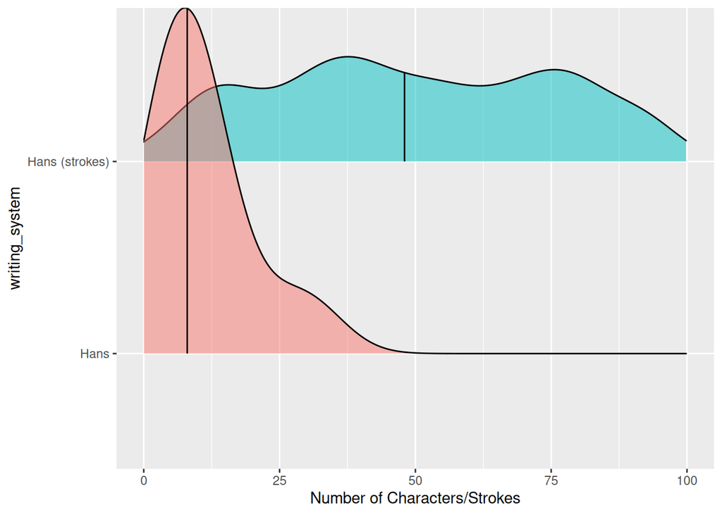

```r
length.plot <- ggplot(estimations.df.selected, aes(x = num.tokens, y = writing_system,
                                    fill = writing_system)) +
  # add density ridges with quantiles = 2, i.e. median as a line
  geom_density_ridges(alpha = 0.5, quantile_lines = TRUE, quantiles = 2) +
  # limit the x-range
  xlim(0, 100) +
  xlab("Number of Characters/Strokes") +
  theme(legend.position = "none")
length.plot
```

Get subset of data points to plot labels.

```r
# how many data points with a given sequence length?
table(estimations.df.selected$num.tokens)
```

```
##
##   2   3   4   5   6   7   8   9  10  11  12  13  14  16  19  24  26  28  29  30
##   2   5   5   4   6   2   5   6   2   4   1   5   4   3   1   1   1   2   3   1
##  31  32  33  36  39  40  46  47  49  53  54  58  59  62  66  68  70  71  73  76
##   2   2   1   1   2   3   1   1   1   2   1   1   1   1   1   1   1   1   1   1
##  79  80  82  90  91  92  94 102 114 117 121 122 137 138 250 260 284 292 316 332
##   3   1   1   1   1   1   1   1   1   1   1   1   1   1   1   1   1   1   1   1
## 341
##   1
```

```r
# choose subset of data points for labeling
labels.df <- estimations.df.selected[estimations.df.selected$num.tokens > 13 &
                                       estimations.df.selected$num.tokens < 20, ]
```

## Entropy rate vs. Unigram Entropy

```r
huni.hrate.chars.plot <- ggplot(estimations.df.selected, aes(x = huni.chars, y =  hrate.chars,
                                                             color = writing_system, size = num.tokens)) +
  geom_point(alpha = 0.3) +
  labs(x = "Unigram entropy for characters/strokes", y = "Entropy rate for characters/strokes") +
  geom_text_repel(data = labels.df,
                  aes(label = text),
                  size = 3,
                  hjust = 0,
                  direction = 'y',
                  fontface = "bold",
                  nudge_x = -3,
                  max.overlaps = Inf,
                  show.legend = FALSE) +
    theme(legend.position = "left") +
  guides(size = guide_legend(title = "No. of chars/strokes"))
huni.hrate.chars.plot <- ggMarginal(huni.hrate.chars.plot, groupFill = T, groupColour = T,
                                  type = "density")
#huni.hrate.chars.plot
```

## TTR vs. Repetition Rate

```r
ttr.rm.chars.plot <- ggplot(estimations.df.selected, aes(x = ttr.chars, y = rm.chars,
                                    colour = writing_system, size = num.tokens)) +
  geom_point(alpha = 0.3) +
  ylim(-0.1, 1) +
  theme(legend.position = "none") +
  labs(x = "TTR for characters/strokes", y = "Repetition rate for characters/strokes") +
  geom_text_repel(data = labels.df,
                   aes(label = text),
                   size = 3,
                   hjust = 0,
                   direction = 'y',
                   fontface = "bold",
                   nudge_x = 1,
                   max.overlaps = Inf,
                   show.legend = FALSE)
ttr.rm.chars.plot <- ggMarginal(ttr.rm.chars.plot, groupFill = T, groupColour = T,
                                  type = "density")
#ttr.rm.chars.plot
```

Combine figures.

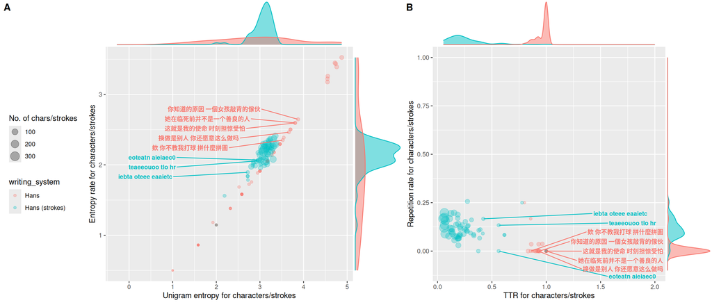

```r
combined.plot <- ggarrange(huni.hrate.chars.plot, ttr.rm.chars.plot, ncol = 2, widths = c(1.3, 1),
                               labels = c("A", "B"))
combined.plot
```

Safe complete figure to file

```r
ggsave("~/Github/PaleoSigns/figures/combinedPlot_chineseStrokes.pdf",
       combined.plot, dpi = 300, width = 14, height = 6, device = cairo_pdf)
```

# Package References

```
## Slowikowski K (2024). _ggrepel: Automatically Position Non-Overlapping
## Text Labels with 'ggplot2'_. R package version 0.9.6,
## <https://CRAN.R-project.org/package=ggrepel>.
```

```
## Attali D, Baker C (2023). _ggExtra: Add Marginal Histograms to
## 'ggplot2', and More 'ggplot2' Enhancements_. R package version 0.10.1,
## <https://CRAN.R-project.org/package=ggExtra>.
```

```
## Kassambara A (2023). _ggpubr: 'ggplot2' Based Publication Ready Plots_.
## R package version 0.6.0, <https://CRAN.R-project.org/package=ggpubr>.
```

```
## Wilke C (2024). _ggridges: Ridgeline Plots in 'ggplot2'_. R package
## version 0.5.6, <https://CRAN.R-project.org/package=ggridges>.
```

# Literature References

Moran, S., Bentz, C., Gutierrez-Vasques, X., Pelloni, O., & Samardzic, T. (2022, June). TeDDi sample: text data diversity sample for language comparison and multilingual NLP. In Proceedings of the Thirteenth Language Resources and Evaluation Conference (pp. 1150-1158).